# Exercises for the meeting of May 10, 2019

## Exercise 5

Create an `sf` object with a point geometry at latitude `36.21` and longitude `-81.19`

```r
(sfc = st_sfc(st_point(c(-81.19,36.21)), crs = 4269))
```

```
## Geometry set for 1 feature
## geometry type:  POINT
## dimension:      XY
## bbox:           xmin: -81.19 ymin: 36.21 xmax: -81.19 ymax: 36.21
## epsg (SRID):    4269
## proj4string:    +proj=longlat +ellps=GRS80 +towgs84=0,0,0,0,0,0,0 +no_defs
```

```
## POINT (-81.19 36.21)
```

## Exercise 6

Query the features of x1 at this point: plot the resulting geometry, and show the attributes associated with this geometry.

```r
geometry=st_intersects(sfc,x1)
```

```
## although coordinates are longitude/latitude, st_intersects assumes that they are planar
## although coordinates are longitude/latitude, st_intersects assumes that they are planar
```

```r
geometry
```

```
## Sparse geometry binary predicate list of length 1, where the predicate was `intersects'
##  1: 1874
```

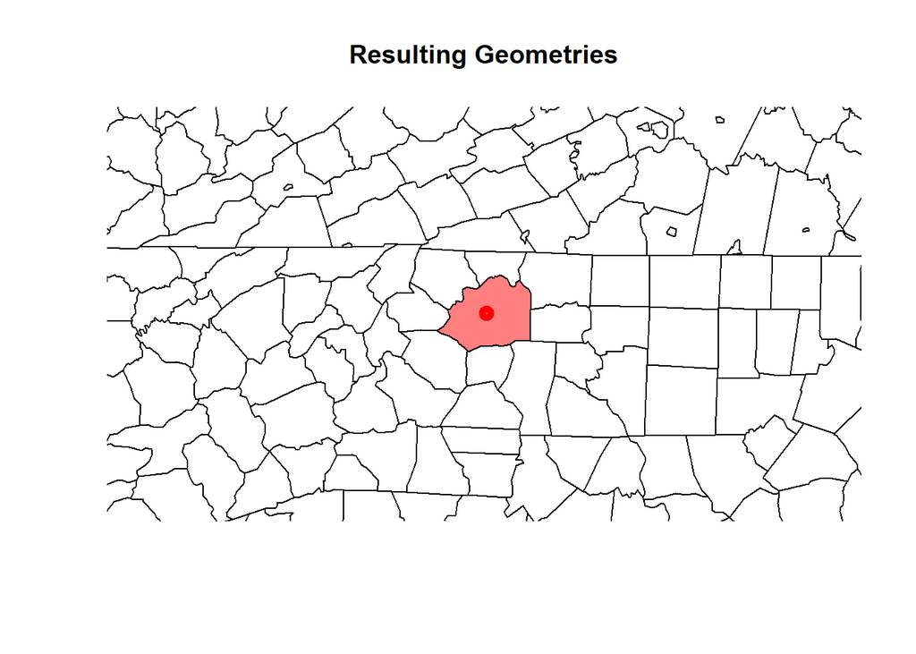

```r
plot(st_geometry(x1[unlist(geometry),]),expandBB = c(2,2,2,2), col=rgb(red = 1, green = 0, blue = 0, alpha = 0.5), main="Resulting Geometries")
plot(st_geometry(x1), add=TRUE)
plot(sfc, expandBB = c(10, 10, 10, 10), col = "red", lwd = 5, add=TRUE)
```

```r
x1[unlist(geometry),]
```

```
## Simple feature collection with 1 feature and 9 fields
## geometry type:  MULTIPOLYGON
## dimension:      XY
## bbox:           xmin: -81.54593 ymin: 35.98946 xmax: -80.87066 ymax: 36.43128
## epsg (SRID):    4269
## proj4string:    +proj=longlat +ellps=GRS80 +towgs84=0,0,0,0,0,0,0 +no_defs
## # A tibble: 1 x 10
##   NAME  STATE_NAME STATE_FIPS CNTY_FIPS FIPS   AREA POP1990 POP2000
##   <chr> <chr>      <chr>      <chr>     <chr> <dbl>   <dbl>   <dbl>
## 1 Wilk~ North Car~ 37         193       37193  767.   59393   64307
## # ... with 2 more variables: POP90_SQMI <int>, Shape <MULTIPOLYGON [Â°]>
```

## Exercise 7

For the `nc` dataset that ships with package `sf`, compute the area of county Columbus

```r
(file <- system.file("gpkg/nc.gpkg", package="sf"))
```

```
## [1] "C:/Users/Violet/Documents/R/win-library/3.5/sf/gpkg/nc.gpkg"
```

```r
(file %>% read_sf()  -> nc)
```

```
## Simple feature collection with 100 features and 14 fields
## geometry type:  MULTIPOLYGON
## dimension:      XY
## bbox:           xmin: -84.32385 ymin: 33.88199 xmax: -75.45698 ymax: 36.58965
## epsg (SRID):    4267
## proj4string:    +proj=longlat +datum=NAD27 +no_defs
## # A tibble: 100 x 15
##     AREA PERIMETER CNTY_ CNTY_ID NAME  FIPS  FIPSNO CRESS_ID BIR74 SID74
##    <dbl>     <dbl> <dbl>   <dbl> <chr> <chr>  <dbl>    <int> <dbl> <dbl>
##  1 0.114      1.44  1825    1825 Ashe  37009  37009        5  1091     1
##  2 0.061      1.23  1827    1827 Alle~ 37005  37005        3   487     0
##  3 0.143      1.63  1828    1828 Surry 37171  37171       86  3188     5
##  4 0.07       2.97  1831    1831 Curr~ 37053  37053       27   508     1
##  5 0.153      2.21  1832    1832 Nort~ 37131  37131       66  1421     9
##  6 0.097      1.67  1833    1833 Hert~ 37091  37091       46  1452     7
##  7 0.062      1.55  1834    1834 Camd~ 37029  37029       15   286     0
##  8 0.091      1.28  1835    1835 Gates 37073  37073       37   420     0
##  9 0.118      1.42  1836    1836 Warr~ 37185  37185       93   968     4
## 10 0.124      1.43  1837    1837 Stok~ 37169  37169       85  1612     1
## # ... with 90 more rows, and 5 more variables: NWBIR74 <dbl>, BIR79 <dbl>,
## #   SID79 <dbl>, NWBIR79 <dbl>, geom <MULTIPOLYGON [Â°]>
```

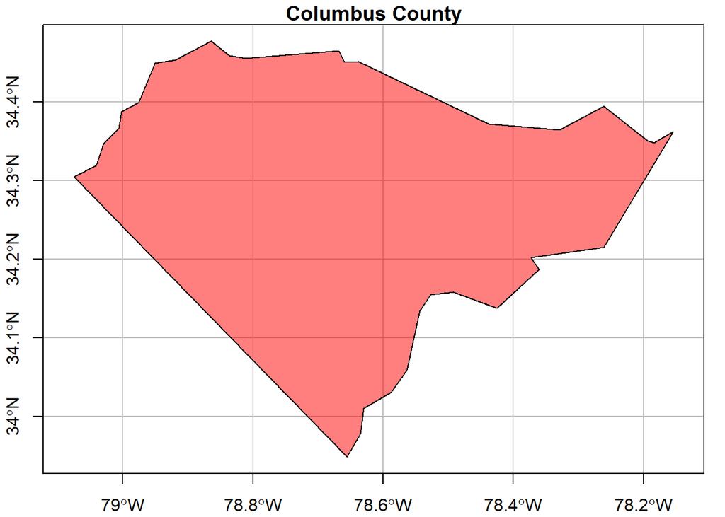

```r
nc%>%select(NAME)%>%filter(NAME=="Columbus") %>%plot(graticule = TRUE, axes = TRUE, col=rgb(red = 1, green = 0, blue = 0, alpha = 0.5), ADD=TRUE, main="Columbus County")
```

```r
columbus = nc %>% filter(NAME == "Columbus")
st_area(columbus)
```

```
## 2450241815 [m^2]
```

## Exercise 8

Compute also the same area after transforming the geometry to `EPSG 2264`, and compare the value with that obtained from the unprojected data; express the difference in a percentage.

```r
nc_newgeo<-nc
(nc_newgeo %>% st_transform(2264) -> nc_newgeo.2264)
```

```
## Simple feature collection with 100 features and 14 fields
## geometry type:  MULTIPOLYGON
## dimension:      XY
## bbox:           xmin: 406262.2 ymin: 48374.87 xmax: 3052887 ymax: 1044158
## epsg (SRID):    2264
## proj4string:    +proj=lcc +lat_1=36.16666666666666 +lat_2=34.33333333333334 +lat_0=33.75 +lon_0=-79 +x_0=609601.2192024384 +y_0=0 +ellps=GRS80 +towgs84=0,0,0,0,0,0,0 +units=us-ft +no_defs
## # A tibble: 100 x 15
##     AREA PERIMETER CNTY_ CNTY_ID NAME  FIPS  FIPSNO CRESS_ID BIR74 SID74
##    <dbl>     <dbl> <dbl>   <dbl> <chr> <chr>  <dbl>    <int> <dbl> <dbl>
##  1 0.114      1.44  1825    1825 Ashe  37009  37009        5  1091     1
##  2 0.061      1.23  1827    1827 Alle~ 37005  37005        3   487     0
##  3 0.143      1.63  1828    1828 Surry 37171  37171       86  3188     5
##  4 0.07       2.97  1831    1831 Curr~ 37053  37053       27   508     1
##  5 0.153      2.21  1832    1832 Nort~ 37131  37131       66  1421     9
##  6 0.097      1.67  1833    1833 Hert~ 37091  37091       46  1452     7
##  7 0.062      1.55  1834    1834 Camd~ 37029  37029       15   286     0
##  8 0.091      1.28  1835    1835 Gates 37073  37073       37   420     0
##  9 0.118      1.42  1836    1836 Warr~ 37185  37185       93   968     4
## 10 0.124      1.43  1837    1837 Stok~ 37169  37169       85  1612     1
## # ... with 90 more rows, and 5 more variables: NWBIR74 <dbl>, BIR79 <dbl>,
## #   SID79 <dbl>, NWBIR79 <dbl>, geom <MULTIPOLYGON [US_survey_foot]>
```

```r
columbus_new = nc_newgeo.2264 %>% filter(NAME == "Columbus")
(area4267=st_geod_area(columbus))
```

```
## 2450241815 [m^2]
```

```r
(area2264=(st_area(columbus_new) %>% set_units(m^2)))
```

```
## 2450426149 [m^2]
```

```r
#New area in percentage
((area2264/area4267)*100)
```

```
## 100.0075 [1]
```

## Exercise 9

Create a plot with the `nc` states outlines that has all states that are partly within 50 km from Columbus filled with color green.

```r
columbusarea = nc[nc$NAME == "Columbus", ]
(selection= st_is_within_distance(columbusarea,nc, dist = 50))
```

```
## Sparse geometry binary predicate list of length 1, where the predicate was `is_within_distance'
##  1: 94, 96, 97, 98, 100
```

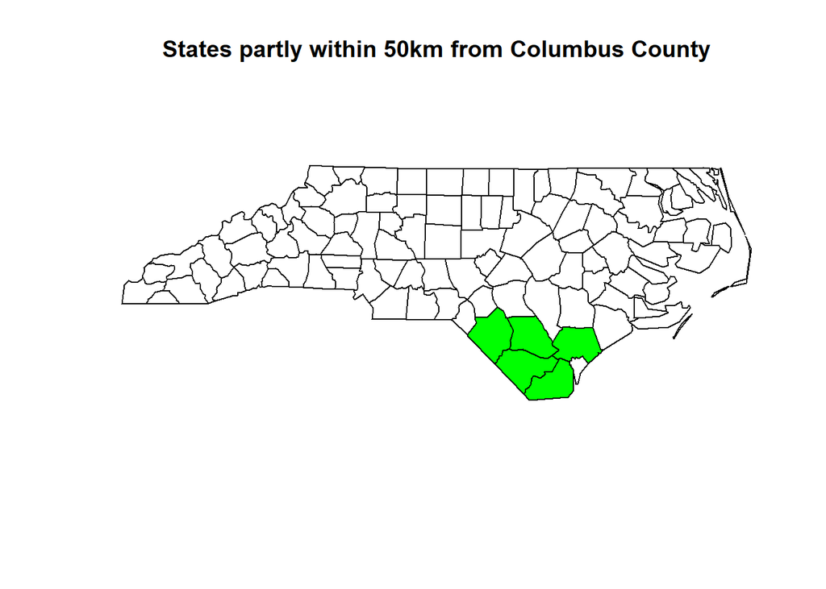

```r
plot(st_geometry(nc), main="States partly within 50km from Columbus County")
plot(st_geometry(nc[unlist(selection),]), add = TRUE, col = 'green')
```

## Exercise 10

Create a plot with the `nc` states outlines that has all states that are entirely within 100 km from Columbus filled with color red.

```r
(columbusarea = nc[nc$NAME == "Columbus", ])
```

```
## Simple feature collection with 1 feature and 14 fields
## geometry type:  MULTIPOLYGON
## dimension:      XY
## bbox:           xmin: -79.0745 ymin: 33.94867 xmax: -78.15479 ymax: 34.4772
## epsg (SRID):    4267
## proj4string:    +proj=longlat +datum=NAD27 +no_defs
## # A tibble: 1 x 15
##    AREA PERIMETER CNTY_ CNTY_ID NAME  FIPS  FIPSNO CRESS_ID BIR74 SID74
##   <dbl>     <dbl> <dbl>   <dbl> <chr> <chr>  <dbl>    <int> <dbl> <dbl>
## 1  0.24      2.37  2232    2232 Colu~ 37047  37047       24  3350    15
## # ... with 5 more variables: NWBIR74 <dbl>, BIR79 <dbl>, SID79 <dbl>,
## #   NWBIR79 <dbl>, geom <MULTIPOLYGON [Â°]>
```

```r
plot(st_geometry(nc),  main="States entirely within 100km from Columbus County")

#Columbus transform for buffer distance calculation
nc_tr = st_transform(columbusarea, 3857)
plot(st_transform(st_buffer(nc_tr, 100000),4267),col=rgb(red = 1, green = 0, blue = 0, alpha = 0.5), border = rgb(red = 1, green = 0, blue = 0, alpha = 0.5), add = TRUE)
otro=st_transform(st_buffer(nc_tr, 100000),4267)
contain_true=st_contains(otro,nc)
```

```
## although coordinates are longitude/latitude, st_contains assumes that they are planar
```

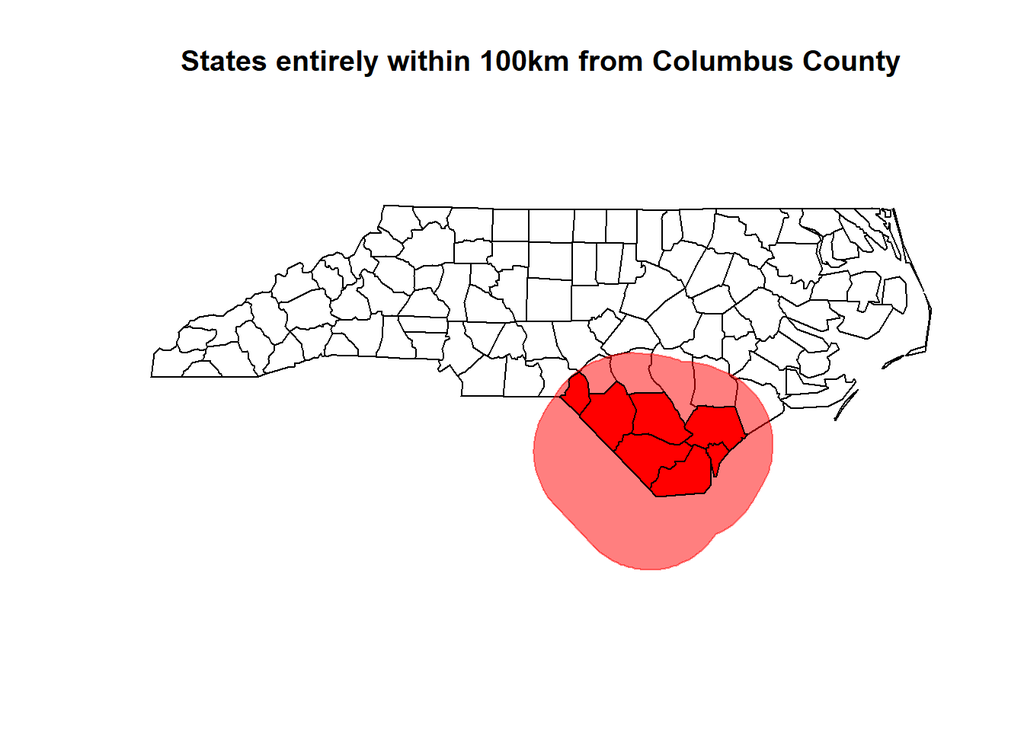

```r
plot(st_geometry(nc[unlist(contain_true),]), add = TRUE, col = 'red')
```